# Applied R in the Classroom

JD Long & Dusty Turner

## Abstract

## Introduction

The Father of Modern Econometrics, Adam Smith, once frustratingly stated:

> The discipline of colleges and universities is in general contrived, not for the benefit of the students, but for the… ease of the masters.[^1]

Adam Smith is making the claim that methods of instruction used by professors are those which are easiest for the instructor, but not necessarily what is best for the student. This is understandable, as research and other administive demands force instructors to rely on tried teaching techniques which are familiar to the teacher and not what will equip the student to be most successful in their career.

The authors of this article will make the case that the R open sourse statistical programming languge can bridge this gap between a Smith’s proverbial teacher’s ease and a student’s benefit. As R continues to be one of the more popular coding languages for statistical analysis with ever increasing technical support, the barriar for entry keeps falling. There are many tools available in R which can aide the teaching process to get students loading and exploring data quickly with manageable overhead for the instructor. With ample open source support, a wide acceptance in industry, and many additional features to explore and present data, teaching with R both satisfies the ease for the instructor and has long term benefit for the students.

This is something we are certain Adam Smith would be proud of.

## The R Ecosystem

The advantages to using R whether in an academic setting or industry are myriad. Since R and all the tooling we discuss below are open source, they have no financial costs to adoption. In addition, R has a very rich ecosystem of add-on packages that expand R and add functionality. These packages add features ranging from libraries to connect to commercial database systems to implementation of new machine learning algorithms.

### CRAN

The online home of R is the Comprehensive R Archive Network, CRAN. CRAN is where a new user can download R and access packages that expand the functionality of R. There are currently more than 10,000 R packages hosted on CRAN for free download. Some new users to R are overwhelmed by the sheer volume of packages. To help make sense of the CRAN ecosystem, CRAN has published CRAN Task Views which organize popular packages into categories of use (e.g. econometrics or spatial statistics). The task views are written and maintained by a subject matter expert. There are more than 35 such task views which can help new R users make sense of the packages availiable in their areas of interest and know which packages are recommended by an expert in their domain of interest. This can give instructors and students a curated view into packages that might match their interests or field of study: https://cran.r-project.org/web/views/

### RStudio

When R is downloaded from CRAN, it comes with an engine for executing R code along with a few core packages for doing statistical analysis and graphics. Collectivly these tools are refered to as “Base R”. Base R comes with a basic text editor for editing and executing R scprits. However most users quickly discover that writing R code is easier wiht an integrated developemnt environment (IDE). The most popular IDE for R is RStudio whcih we highly recommend for teaching.

RStudio desktop can be downloaded for free from RStudio.com. In additon to the desktop IDE, RStudio makes a server based IDE for using R on remote machines. RStudio server also is availiable in a professional version that offers more features such as authentication and collaborative editing. RStudio offers its professional tools to academics for free. Go to https://www.rstudio.com/pricing/academic-pricing/ for more info.

For many instructors, the freely availiable RStudio.cloud service (http://rstudio.cloud) greatly simplifies instruction by providing a fully functional and configured R and RStudio environment running on cloud hosted hardware. For the rest of this article we will exclusivly use RStudio.cloud in our examples. Instructors can set up projects in RStudio.cloud and share those projects with students to simplify distributing course material.

[figure not shown]

RStudio.cloud

Instructors who don’t want to use the cloud solutions, or can’t because of connectivity restrictions, can download and install R and RStudio on local hardware. For details on downloading and installing, see section 1.1 in R Cookbook Second Edition, available online at https://rc2e.com/gettingstarted#recipe-id001.

### Projects

RStudio introduces a powerful organizational tool called an RStudio Project. Projects help you by doing the following:

- Storing RStudio project settings
- Restoring window position in RStudio so when you return to a project you can pick up exactly where you left off
- Setting the working directory

RStudio creates a project file with an *.Rproj* extension in the project directory. RStudio also creates a hidden directory, *.Rproj.user*, for temporary files related to your project.

We’ve found that helping students organieze their files using projects from the start helps them build good practices and prevent lost files and file path related issues that can flummox new learners. Although instructors should expect to teach the basics of absolute and relative file paths, as this concept is sometimes new to learners and can slow learning.

### Tidyverse

In addition to the RStudio IDE, the RStudio company supports the development of a number of open source packages designed to work together to make R easier to use and faster to learn. These libraries are collectivly known as the “Tidyverse”. The most concise definition of the Tidyverse comes directly from its originator and core maintainer, Hadley Wickham:

> The tidyverse is a set of packages that work in harmony because they share common data representations and API design. The tidyverse package is designed to make it easy to install and load core packages from the tidyverse in a single command. The best place to learn about all the packages in the tidyverse and how they fit together is *[R for Data Science](http://r4ds.had.co.nz)*.

(https://blog.rstudio.com/2016/09/15/tidyverse-1-0-0/)

The authors have had very good experiences with introducing learners to the Tidyverse from the very beginning of the learning journey because these tools help learners see very quick successes which, in turn, keeps them engaged in the learning process. The popular plotting package `ggplot2` and the data manipulation package `dplyr` are both core Tidyverse packages.

The Tidyverse meta-package, like any CRAN package, can be installed from the R Console:

```r
install.packages("tidyverse")
```

#### Tidyverse Packages

When a user installs the Tidyverse, 19 packages are installed. Then when the user loads the tidyverse using `library(tidyverse)` a core subset of 8 packages are loaded into R. To use any of the pacakges not loaded with the core Tidyverse a user must explicitly load those packages (e.g. `library(readxl)`) or call the packages using the package name prefix (e.g. `readxl::read_xlsx()` to run the `read_xlsx()` function from the `readxl` package).

The packages listed below are in the “Core Tidyverse” and get loaded with `library(tidyverse)`.

*Core Tidyverse*

`ggplot2`: data visualisation  
`dplyr`: data manipulation  
`tidyr`: data reshaping  
`readr`: data import  
`purrr`: functional programming  
`tibble`: tidy dataframes  
`stringr`: string manipulation  
`forcats`: factor use

*Additional Tidyverse*

There are 11 additional Tidyverse packages that get installed, but not automatically loaded. These add specialized functions for more specialized uses.

`hms`: time manipulation `lubridate`: date manipulation  
`modelr`: model building  
`broom`: output manipulation  
`feather`: reading / writing data `haven`: reading / writing data `httr`: accessing html `jsonlite`: JSON manipulation `readxl`: reading Excel files `rvest`: scrape html data `xml2`: Data inport

More info on each can be found at https://tidyverse.tidyverse.org

## Harnessing The Power of R and the Tidyverse

In the following sections, we will highlight some of the features of R and the `tidyverse` and how they can be useful in a classroom setting while teaching new students.

### Loading Data (Gapminder)

To aide our instructions, we will explore the Gapminder data set. The Gapminder dataset is created by the Gapminder Foundation which is a non-profit which promots sustainable global development. https://www.gapminder.org

Showing students how to load in example data is a crucial first step. Data can be easily loaded from the local file system:

```r
library(tidyverse)
gapminder <- read_csv("01_data/gapminder.csv")
```

Once the student reads the the data into R, the environment tab in the top right of the computer will reflect that the data is loaded.

[figure not shown]

Environment With Gapminder Data

### Initial Data Exploration

Simply outputting the code can tell students a bundle of information about the data just loaded. Lets look at the output below.

```r
gapminder
```

```
## # A tibble: 1,704 x 6
##    country     continent  year lifeExp      pop gdpPercap
##    <chr>       <chr>     <dbl>   <dbl>    <dbl>     <dbl>
##  1 Afghanistan Asia       1952    28.8  8425333      779.
##  2 Afghanistan Asia       1957    30.3  9240934      821.
##  3 Afghanistan Asia       1962    32.0 10267083      853.
##  4 Afghanistan Asia       1967    34.0 11537966      836.
##  5 Afghanistan Asia       1972    36.1 13079460      740.
##  6 Afghanistan Asia       1977    38.4 14880372      786.
##  7 Afghanistan Asia       1982    39.9 12881816      978.
##  8 Afghanistan Asia       1987    40.8 13867957      852.
##  9 Afghanistan Asia       1992    41.7 16317921      649.
## 10 Afghanistan Asia       1997    41.8 22227415      635.
## # … with 1,694 more rows
```

From the output above, one can see the `gapminder` dataset is a `tibble` consisting of 1,704 observational units with 6 columns of information. When reading in data, the `read_csv` command identifies the most likely class of data for each column lists the class below the column name. We can see that we have a mix of `character`s and `double`s. A `tibble` is a Tidyverse take on R’s traditional `data.frame`. We’ve found that it usually is sufficient to tell students that `tibble` is a table. Since the goal is to get students using data to *do* things we often don’t spend excessive time on definitions and instead focus on getting students doing something interesting.

Students also notice that printing out the data does not provude all the information they would like to know. One can see that the data has information about countries, but are they all Afghanistan? Likely no, as you can see there are 1,694 more rows and they probably are not all Afghanistan. Lets look at other ways to understand the data.

We recommend using the `skim` command from the `skimr` library. You may need to download the `skimr` package from CRAN.

```r
install.packages("skimr")
```

```r
library(skimr)
kable(skim(gapminder))
```

Skim summary statistics  
n obs: 1704  
n variables: 6

Variable type: character

| variable | missing | complete | n | min | max | empty | n_unique |
| --- | --- | --- | --- | --- | --- | --- | --- |
| continent | 0 | 1704 | 1704 | 4 | 8 | 0 | 5 |
| country | 0 | 1704 | 1704 | 4 | 24 | 0 | 142 |

Variable type: numeric

| variable | missing | complete | n | mean | sd | p0 | p25 | p50 | p75 | p100 | hist |
| --- | --- | --- | --- | --- | --- | --- | --- | --- | --- | --- | --- |
| gdpPercap | 0 | 1704 | 1704 | 7215.33 | 9857.45 | 241.17 | 1202.06 | 3531.85 | 9325.46 | 113523.13 | ▇▁▁▁▁▁▁▁ |
| lifeExp | 0 | 1704 | 1704 | 59.47 | 12.92 | 23.6 | 48.2 | 60.71 | 70.85 | 82.6 | ▁▂▅▅▅▅▇▃ |
| pop | 0 | 1704 | 1704 | 29601212.32 | 106157896.74 | 60011 | 2793664 | 7023595.5 | 19585221.75 | 1318683096 | ▇▁▁▁▁▁▁▁ |
| year | 0 | 1704 | 1704 | 1979.5 | 17.27 | 1952 | 1965.75 | 1979.5 | 1993.25 | 2007 | ▇▃▇▃▃▇▃▇ |

This gives students a much better view of the data. `skim` seperates the data by class and provides important information for each data type. We find that the `skim` function gives students the quickest and best description of the data. Other options of presenting detailed information about the data include the `summary(gapminder)`, `glimse(gapminder)`, and `str(gapminder)`

In the output above, for each class of data (`character`/`numeric`), `skim` provides how many missing, complete, and total (n) observations for each column.

For the character class, `skim` provides additional information about each column. This includes the min/max length of each character string as well as the number of unique (n_unique) observations.

For the numeric class, `skim` provides mean, standard deviation (sd), and percentile breaks (p0, p25,…,p100). It also provides a small histogram to help visualize the distribution of your numeric data (hist).

This likely does not satisfy the students’s desire to understand the data as we still do not understand which countries are in the data among other curiosities. We will provide more indepth methods of understanding the data in the plotting and Exploratory Data Analysis (EDA) section after we look briefly at the 6 `dplyr` verbs that allow students to begin rapidly understanding the data.

### `dplyr` Verbs

Almost any time a student wors with data, they will need to manipulate that data in some way. In this next section, we will introduce the main 6 `dplyr` verbs to help wrangle data to gain additional insight. These verbs, `select`, `filter`, `mutate`, `group_by`, `summarize`, `arrange` are explained in detail below.

In order to motivate a student’s use of the aformentioned verbs, we’ll look to answer the following question:

**What is the average GDP per country since 1980?**

#### Verb 1: `select`

To begin, we only need to work with certain columns. The relevent columns to this question are `country`, `year`, `pop`, and `gdpPercap`. We can make this selection using the `select` function. The first argument in the `select` function is the data we which to select from. The subsequent arguments are the names of the columns from the data we wish to select. In the code below, we save our selected columns into a new tibble called `gapminder_selected`.

```r
gapminder_selected = select(gapminder, country, year, pop, gdpPercap)
gapminder_selected
```

```
## # A tibble: 1,704 x 4
##    country      year      pop gdpPercap
##    <chr>       <dbl>    <dbl>     <dbl>
##  1 Afghanistan  1952  8425333      779.
##  2 Afghanistan  1957  9240934      821.
##  3 Afghanistan  1962 10267083      853.
##  4 Afghanistan  1967 11537966      836.
##  5 Afghanistan  1972 13079460      740.
##  6 Afghanistan  1977 14880372      786.
##  7 Afghanistan  1982 12881816      978.
##  8 Afghanistan  1987 13867957      852.
##  9 Afghanistan  1992 16317921      649.
## 10 Afghanistan  1997 22227415      635.
## # … with 1,694 more rows
```

Once we view the data, we see that we now have 1704 rows with 4 columns.

#### Verb 2: `filter`

To further answer our question, we need to filter our data down to the years of interest. We can achieve this goal using the `filter` function. Like the `select` function, the first argument in the `filter` function is the data and subsequent argument is the logical statement of which you wish to filter. In the code below, we filter our selected data and save our filtered data into a new tibble called `gapminder_filtered`.

```r
gapminder_filtered = filter(gapminder_selected, year >= 1980)
gapminder_filtered
```

```
## # A tibble: 852 x 4
##    country      year      pop gdpPercap
##    <chr>       <dbl>    <dbl>     <dbl>
##  1 Afghanistan  1982 12881816      978.
##  2 Afghanistan  1987 13867957      852.
##  3 Afghanistan  1992 16317921      649.
##  4 Afghanistan  1997 22227415      635.
##  5 Afghanistan  2002 25268405      727.
##  6 Afghanistan  2007 31889923      975.
##  7 Albania      1982  2780097     3631.
##  8 Albania      1987  3075321     3739.
##  9 Albania      1992  3326498     2497.
## 10 Albania      1997  3428038     3193.
## # … with 842 more rows
```

Once we view the data, we see that our data now consist of years since 1980.

#### Verb 3: `mutate`

The next step in answering our question is creating a column that contains the information of interest. The `mutate` function creats new columns according to a specific function that we provide. To answer our question, we need to determine the GDP in each year. To find the GDP, we need to multiply the `gdpPercap` by the `pop`. Similar to the previous two verbs, the first argument in the `mutate` function is the data. Subsequent arguments are columns you wish to create with corresponding formulas. In the code below, we mutate our filtered data and save our mutated data into a new tibble called `gapminder_mutated`.

```r
gapminder_mutated = mutate(gapminder_filtered, GDP = gdpPercap * pop)
gapminder_mutated
```

```
## # A tibble: 852 x 5
##    country      year      pop gdpPercap          GDP
##    <chr>       <dbl>    <dbl>     <dbl>        <dbl>
##  1 Afghanistan  1982 12881816      978. 12598563401.
##  2 Afghanistan  1987 13867957      852. 11820990309.
##  3 Afghanistan  1992 16317921      649. 10595901589.
##  4 Afghanistan  1997 22227415      635. 14121995875.
##  5 Afghanistan  2002 25268405      727. 18363410424.
##  6 Afghanistan  2007 31889923      975. 31079291949.
##  7 Albania      1982  2780097     3631. 10094200603.
##  8 Albania      1987  3075321     3739. 11498418358.
##  9 Albania      1992  3326498     2497.  8307722183.
## 10 Albania      1997  3428038     3193. 10945912519.
## # … with 842 more rows
```

Once we view the data, we see the new column, GDP, has been added to the end of our tibble.

#### Verb 4: `group_by`

The next step in answering our question will be to group our data by the topic of interest. In this instance, since we want to know GDP by country, we need to group or data by country. A way to conceptualize this step is to think of placing each group of data into a specific room. In subsequent steps we will apply a function to each group (or room) of data. Just like the previous verbs, the first argument in the `group_by` function is the data. The following arguments are the columns you wish to group by. In the code below, we group our mutated data and save our grouped data into a new tibble called `gapminder_grouped`.

```r
gapminder_grouped =  group_by(gapminder_mutated, country)
gapminder_grouped
```

```
## # A tibble: 852 x 5
## # Groups:   country [142]
##    country      year      pop gdpPercap          GDP
##    <chr>       <dbl>    <dbl>     <dbl>        <dbl>
##  1 Afghanistan  1982 12881816      978. 12598563401.
##  2 Afghanistan  1987 13867957      852. 11820990309.
##  3 Afghanistan  1992 16317921      649. 10595901589.
##  4 Afghanistan  1997 22227415      635. 14121995875.
##  5 Afghanistan  2002 25268405      727. 18363410424.
##  6 Afghanistan  2007 31889923      975. 31079291949.
##  7 Albania      1982  2780097     3631. 10094200603.
##  8 Albania      1987  3075321     3739. 11498418358.
##  9 Albania      1992  3326498     2497.  8307722183.
## 10 Albania      1997  3428038     3193. 10945912519.
## # … with 842 more rows
```

The reader will notice that there apears to be no change to the data. This is mostly true as we have simply told R that we would like to apply future functions over each group of data instead of over the entire tibble. The only difference in output is the a note explaining the what the data has been grouped into and the number of groups. In this case, it explains the data is grouped by `country` and that there are 142 groups.

#### Verb 5: `summarise`

```r
gapminder_summarised = summarise(gapminder_grouped, AVG_GDP = mean(GDP))
gapminder_summarised
```

```
## # A tibble: 142 x 2
##    country           AVG_GDP
##    <chr>               <dbl>
##  1 Afghanistan  16430025591.
##  2 Albania      13062766192.
##  3 Algeria     148613140752.
##  4 Angola       28940373965.
##  5 Argentina   353071702131.
##  6 Australia   477639321504.
##  7 Austria     225388780040.
##  8 Bahrain      12397050418.
##  9 Bangladesh  119954904364.
## 10 Belgium     271944511091.
## # … with 132 more rows
```

We now have an answer to our question. The tibble above shows the average GDP per country since 1980.

#### Verb 6: `arrange`

However, we can refine our data to provide more understanding. Currently, our data is sorted alphabetically by country. This does not provide much insight. We can use the `arrange` function to sort the data by average GDP; both assending and descending. Like all other verbs, the first argument in the `arrange` function is the data. The following argument is the column you wish to sort by. In the code below, we arrange our summarised data and save our arranged data into a new tibble called `gapminder_arranged`.

```r
gapminder_arragned = arrange(gapminder_summarised, AVG_GDP)
gapminder_arragned
```

```
## # A tibble: 142 x 2
##    country                      AVG_GDP
##    <chr>                          <dbl>
##  1 Sao Tome and Principe     213138942.
##  2 Comoros                   585013190.
##  3 Guinea-Bissau             788263198.
##  4 Gambia                    806874307.
##  5 Djibouti                  894915489.
##  6 Liberia                  1274437021.
##  7 Lesotho                  2041066151.
##  8 Equatorial Guinea        2131596160.
##  9 Eritrea                  2545841271.
## 10 Central African Republic 2670573945.
## # … with 132 more rows
```

We see, from the output above, the countries with the smalled average GDP since 1980.

It may be more interesting, however, to sort the average GDP in descending order so we can learn the countries with the highest average GDP. To do this we simply place a `-` sign in front of `AVG_GDP` in the call above.

```r
gapminder_arragned_descending = arrange(gapminder_summarised, -AVG_GDP)
gapminder_arragned_descending
```

```
## # A tibble: 142 x 2
##    country        AVG_GDP
##    <chr>            <dbl>
##  1 United States  9.20e12
##  2 Japan          3.28e12
##  3 China          2.96e12
##  4 Germany        2.20e12
##  5 United Kingdom 1.48e12
##  6 France         1.48e12
##  7 India          1.39e12
##  8 Italy          1.33e12
##  9 Brazil         1.27e12
## 10 Mexico         9.26e11
## # … with 132 more rows
```

#### Simplifying Code with the Pipe Operator: `%>%`

After helping learners see how each function works we can introduce the pipe operator (`%>%`) that can be used to chain together commands and pass the results of one functiopn directly into the next function. This can result in very logical data manipulation steps that are easy to learn and easy to understand:

```r
gapminder_arragned_descending_chained =
  gapminder %>%
  select(country, year, pop, gdpPercap) %>%
  filter(year >= 1980) %>%
  mutate(GDP = gdpPercap * pop) %>%
  group_by(country) %>%
  summarise(AVG_GDP = mean(GDP)) %>%
  arrange(-AVG_GDP)

gapminder_arragned_descending_chained
```

```
## # A tibble: 142 x 2
##    country        AVG_GDP
##    <chr>            <dbl>
##  1 United States  9.20e12
##  2 Japan          3.28e12
##  3 China          2.96e12
##  4 Germany        2.20e12
##  5 United Kingdom 1.48e12
##  6 France         1.48e12
##  7 India          1.39e12
##  8 Italy          1.33e12
##  9 Brazil         1.27e12
## 10 Mexico         9.26e11
## # … with 132 more rows
```

Some students may struggle to grasp this coding technique. It may be helpful to explain the pipe in the following way: A pipe takes the result of the previous fuction and ‘pipes’ it into the first argument of the next function. In that way, we can chain together our verbs to manipulate and gain insight on the data.

### Plotting/EDA

From the preceeding example, you can see how to gain insight from data by manipulating the tibble with `dplyr` verbs. A more helpful way to gain insight from data is by viewing it graphically. We’ll go over plotting basics

Typically before building any models or doing other analysis, students benefit from learning to do basic exploritory data analysis (EDA). One tool for getting students a quick win with learning data visualization is to use `ggplot2` with the helper package `esquisse` to give them a graphical user interface that helps them write `ggplot2` code.

Since `esquisse` is a CRAN package, it can be installed by running `install.packages("esquisse")`. After installation, `esquisse` shows up in the *Addins* menu of RStudio:

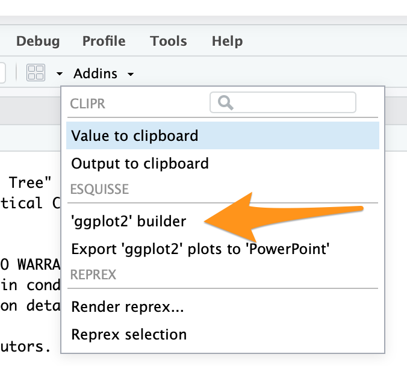

Addins menue

The `'ggplot2' builder` menu option opens the graphical interface for building `ggplot2` graphics using a helper UI. Below is how the `esquisse` interface appears with the `gapminder` data selected:

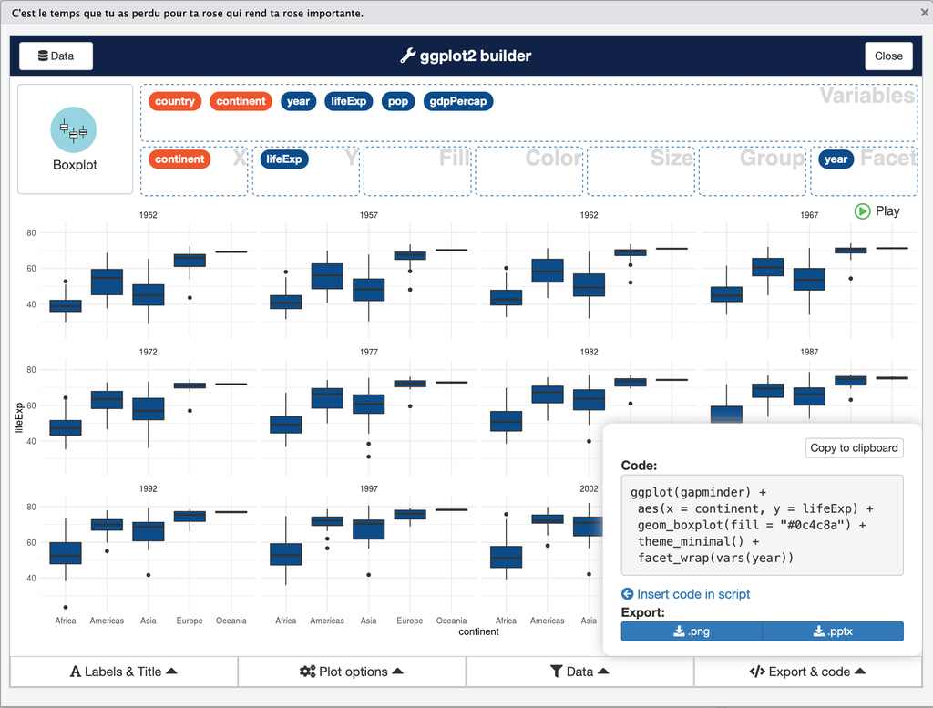

esquisse UI

The strength of `esquisse` is that it produces the `ggplot2` code that allows the R learner to see how they can build the syntax themselves in the future. This gives students an increadible learning boost that reduces the likelyhood that they will get stuck when trying to make their first `ggplot2` figures. For more information about `esquisse` see the project CRAN web site: https://cran.r-project.org/web/packages/esquisse/readme/README.html

### Regression

One of the more common statistical tools students learn in Econometrics is Linear Regression. It happens to be one of many tools in R’s arsonel.

In the base stats package and with one additional library, R offers easy to execute and simple to understand tools to execute everything we would expect a student to learn in linear regression.

To highlight these tool, lets explore the linear relationship between several variables and life expectancy (`lifeExp`) in the Gapminder data.

#### Simple Linear Regression

To execute linear regression, we need to specify two arguments in the `lm` function: The formula and the data. As you can see in the example below, our formula is in the format `y~x` - pronounced y by x. As expected, the `data` is equal to `gapminder`.

```r
model1 = lm(formula = lifeExp ~ gdpPercap, data = gapminder)
```

R executes this command and saves it as `model1`. To retrieve our simple linear regression model, we place `model1` in the summary command below.

```r
summary(model1)
```

```
##
## Call:
## lm(formula = lifeExp ~ gdpPercap, data = gapminder)
##
## Residuals:
##     Min      1Q  Median      3Q     Max
## -82.754  -7.758   2.176   8.225  18.426
##
## Coefficients:
##                Estimate  Std. Error t value            Pr(>|t|)
## (Intercept) 53.95556088  0.31499494  171.29 <0.0000000000000002 ***
## gdpPercap    0.00076488  0.00002579   29.66 <0.0000000000000002 ***
## ---
## Signif. codes:  0 '***' 0.001 '**' 0.01 '*' 0.05 '.' 0.1 ' ' 1
##
## Residual standard error: 10.49 on 1702 degrees of freedom
## Multiple R-squared:  0.3407, Adjusted R-squared:  0.3403
## F-statistic: 879.6 on 1 and 1702 DF,  p-value: < 0.00000000000000022
```

As you can see from the output, the student sees pertinent information about the model to include the equation, a small summary of the residuals, regression coefficients, P Values, and familiar model evaluation statistics such as $R^2$ and Adjusted $R^2$.

Adjusting the linear model is simple. Should we desire to add another factor to the model, we can do it simply by adding it to the formula like the example below.

```r
model2 = lm(formula = lifeExp ~ gdpPercap + year, data = gapminder)
summary(model2)
```

```
##
## Call:
## lm(formula = lifeExp ~ gdpPercap + year, data = gapminder)
##
## Residuals:
##     Min      1Q  Median      3Q     Max
## -67.262  -6.954   1.219   7.759  19.553
##
## Coefficients:
##                  Estimate    Std. Error t value            Pr(>|t|)
## (Intercept) -418.42425945   27.61713769  -15.15 <0.0000000000000002 ***
## gdpPercap      0.00066973    0.00002447   27.37 <0.0000000000000002 ***
## year           0.23898275    0.01397107   17.11 <0.0000000000000002 ***
## ---
## Signif. codes:  0 '***' 0.001 '**' 0.01 '*' 0.05 '.' 0.1 ' ' 1
##
## Residual standard error: 9.694 on 1701 degrees of freedom
## Multiple R-squared:  0.4375, Adjusted R-squared:  0.4368
## F-statistic: 661.4 on 2 and 1701 DF,  p-value: < 0.00000000000000022
```

Lastly, R’s linear model function is flexible enought to easily add interaction terms. Teaching using this syntax is a simple and easy to demonstrate.

```r
model3 = lm(formula = lifeExp ~ gdpPercap * year, data = gapminder)
summary(model3)
```

```
##
## Call:
## lm(formula = lifeExp ~ gdpPercap * year, data = gapminder)
##
## Residuals:
##     Min      1Q  Median      3Q     Max
## -54.234  -7.314   1.002   7.951  19.780
##
## Coefficients:
##                      Estimate     Std. Error t value             Pr(>|t|)
## (Intercept)    -353.222539884   32.673833697 -10.811 < 0.0000000000000002
## gdpPercap        -0.008754192    0.002547055  -3.437             0.000602
## year              0.206000927    0.016528783  12.463 < 0.0000000000000002
## gdpPercap:year    0.000004754    0.000001285   3.700             0.000222
##
## (Intercept)    ***
## gdpPercap      ***
## year           ***
## gdpPercap:year ***
## ---
## Signif. codes:  0 '***' 0.001 '**' 0.01 '*' 0.05 '.' 0.1 ' ' 1
##
## Residual standard error: 9.658 on 1700 degrees of freedom
## Multiple R-squared:  0.442,  Adjusted R-squared:  0.441
## F-statistic: 448.8 on 3 and 1700 DF,  p-value: < 0.00000000000000022
```

#### Linear Regression Modeling Assumptions

One of the staples of teaching linear regression is helping students determine if their model meets the four assumptions necessary for a linear model to be valid:

1. Independent Observations
2. Normal Errors
3. Consistant Variance
4. Linear Relationships

Independent Observations:

To determine independence, we must know how the data was collected. There are likely independence issues as the data on each country in the Gapminder collection are likely influenced by each other. We’ll acknowledge this and proceed on with the analysis.

Other Assumptions:

To verify the other assumptions, we need to create two plots. The residual plots and a qqplot.

To create the residual plots, we’ll explore model 2. We need to create three plots. The y axes for each plot will be the residuals (the observed life expectancy - the life expectancy predicted by our model). The x axis for our three plots will be GDP Per Capita, year, and our predicted values.

We will need to crete the residuals to execute these plots. We can do this as the code below specifies.

```r
predictions = predict.lm(object = model2, newdata = gapminder)
```

We can easily add these predictions to our tibble for plotting with the tools we’ve previously learned. Furthermore, we can calculate the redisuals in the next step.

```r
gapminder_predicted = gapminder %>%
  mutate(Fitted = predictions) %>%
  mutate(residual = lifeExp - predictions)
head(gapminder_predicted)
```

```
## # A tibble: 6 x 8
##   country     continent  year lifeExp      pop gdpPercap Fitted residual
##   <chr>       <chr>     <dbl>   <dbl>    <dbl>     <dbl>  <dbl>    <dbl>
## 1 Afghanistan Asia       1952    28.8  8425333      779.   48.6    -19.8
## 2 Afghanistan Asia       1957    30.3  9240934      821.   49.8    -19.5
## 3 Afghanistan Asia       1962    32.0 10267083      853.   51.0    -19.0
## 4 Afghanistan Asia       1967    34.0 11537966      836.   52.2    -18.2
## 5 Afghanistan Asia       1972    36.1 13079460      740.   53.3    -17.3
## 6 Afghanistan Asia       1977    38.4 14880372      786.   54.6    -16.1
```

Now we can use `ggplot` to create the three residual plots.

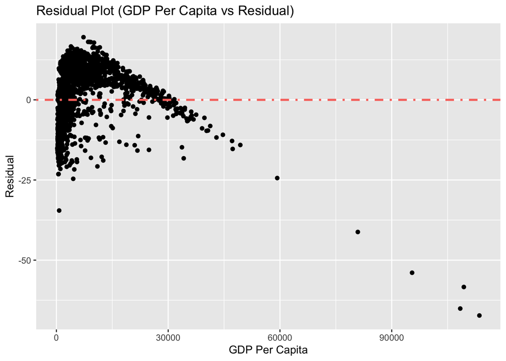

```r
gapminder_predicted %>%
  ggplot(aes(x = gdpPercap, y = residual)) +
  geom_point() +
  geom_hline(aes(yintercept = 0, color = "red"),
             linetype = "dotdash",
             size = 1) +
  labs(x = "GDP Per Capita", y = "Residual", title = "Residual Plot (GDP Per Capita vs Residual)") +
  theme(legend.position = "none")
```

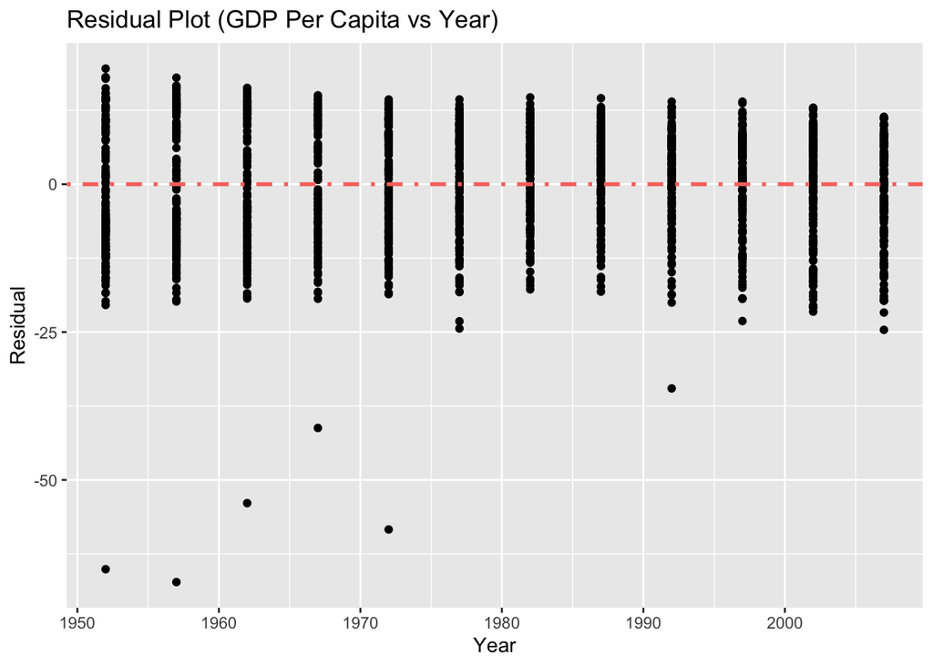

```r
gapminder_predicted %>%
  ggplot(aes(x = year, y = residual)) +
  geom_point() +
  geom_hline(aes(yintercept = 0, color = "red"),
             linetype = "dotdash",
             size = 1) +
  labs(x = "Year", y = "Residual", title = "Residual Plot (GDP Per Capita vs Year)") +
  theme(legend.position = "none")
```

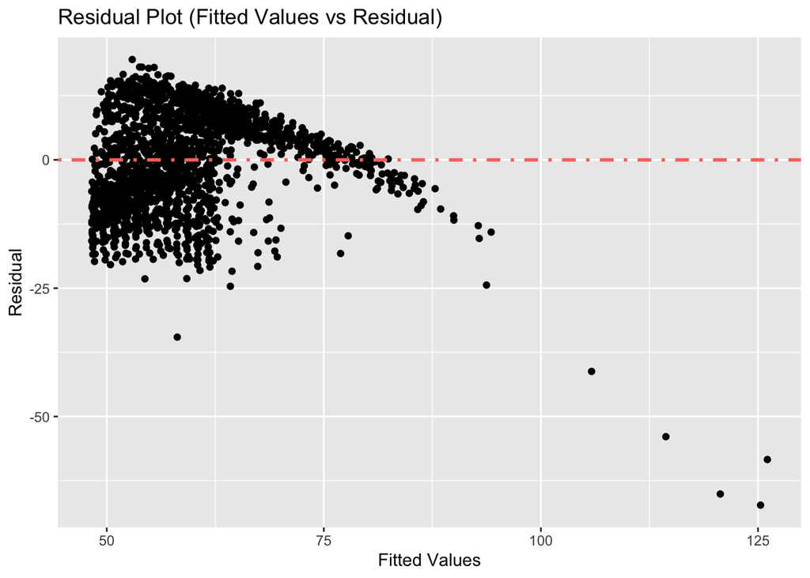

```r
gapminder_predicted %>%
  ggplot(aes(x = Fitted, y = residual)) +
  geom_point() +
  geom_hline(aes(yintercept = 0, color = "red"),
             linetype = "dotdash",
             size = 1) +
  labs(x = "Fitted Values", y = "Residual", title = "Residual Plot (Fitted Values vs Residual)") +
  theme(legend.position = "none")
```

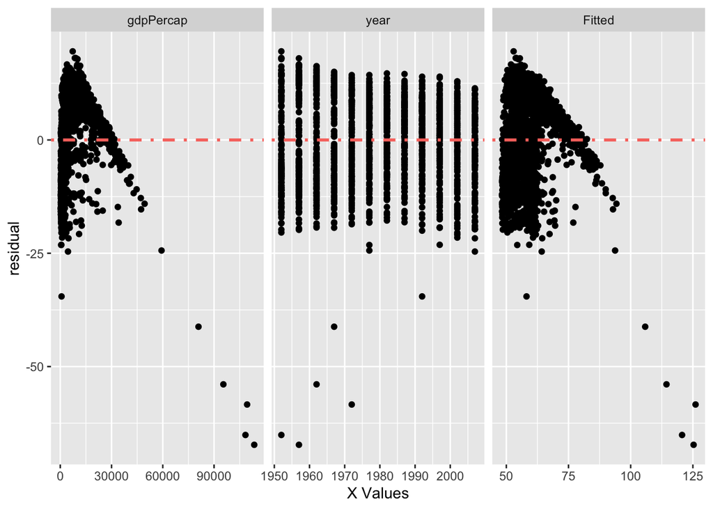

```r
gapminder_predicted %>%
  mutate(Predictions = Fitted) %>%
  # mutate(year = as.factor(year)) %>%
  gather(XAxis, Value, year, gdpPercap, Fitted) %>%
  ggplot(aes(x = Value, y = residual)) +
  geom_point() +
  facet_wrap(~ forcats::fct_relevel(XAxis, "gdpPercap", "year", "Fitted"),
             scales = "free_x") +
  geom_hline(aes(yintercept = 0, color = "red"),
             linetype = "dotdash",
             size = 1) +
  labs(x = "X Values", "Residuals", "Residual Plots") +
  theme(legend.position = "none")
```

The second plot we need to look at is the qqplot.

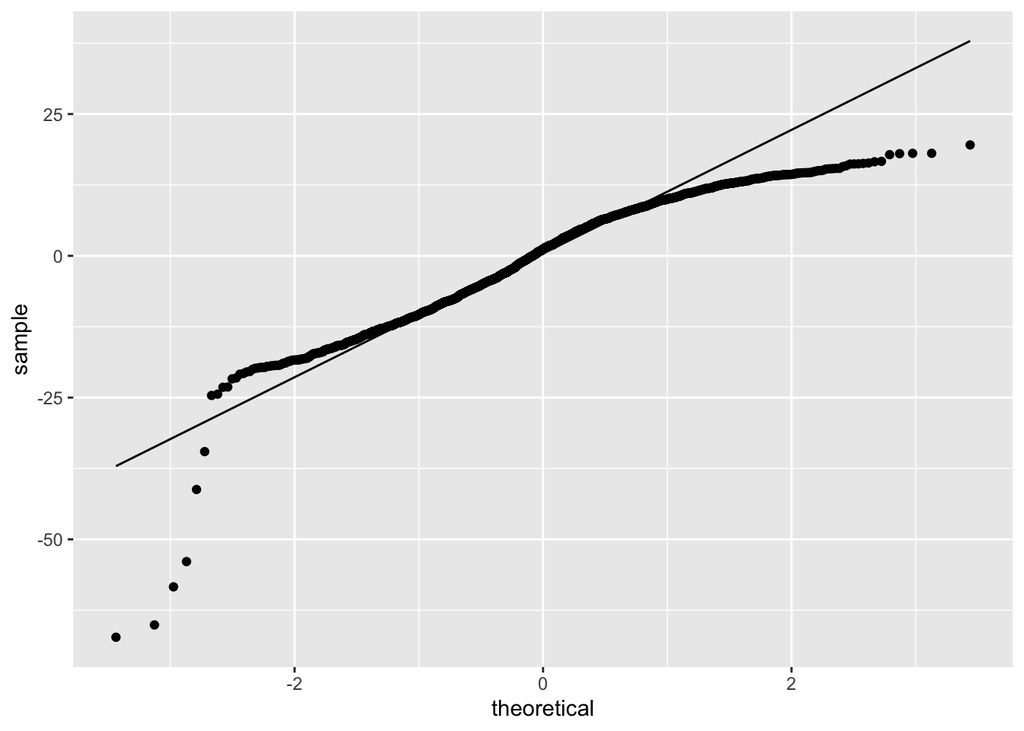

```r
gapminder_predicted %>%
  ggplot(aes(sample = residual)) +
  stat_qq() +
  stat_qq_line()
```

```r
modeladj = lm(formula = lifeExp ~ log(gdpPercap) + year, data = gapminder)
summary(modeladj)
```

```
##
## Call:
## lm(formula = lifeExp ~ log(gdpPercap) + year, data = gapminder)
##
## Residuals:
##      Min       1Q   Median       3Q      Max
## -27.2291  -3.8454   0.6065   4.7737  17.8644
##
## Coefficients:
##                   Estimate  Std. Error t value            Pr(>|t|)
## (Intercept)    -391.051354   19.418290  -20.14 <0.0000000000000002 ***
## log(gdpPercap)    7.770320    0.138084   56.27 <0.0000000000000002 ***
## year              0.195569    0.009927   19.70 <0.0000000000000002 ***
## ---
## Signif. codes:  0 '***' 0.001 '**' 0.01 '*' 0.05 '.' 0.1 ' ' 1
##
## Residual standard error: 6.877 on 1701 degrees of freedom
## Multiple R-squared:  0.7169, Adjusted R-squared:  0.7165
## F-statistic:  2153 on 2 and 1701 DF,  p-value: < 0.00000000000000022
```

We’ll now re-run the same code as before and look at the change to our residuals to see how our change impacts our assumptions.

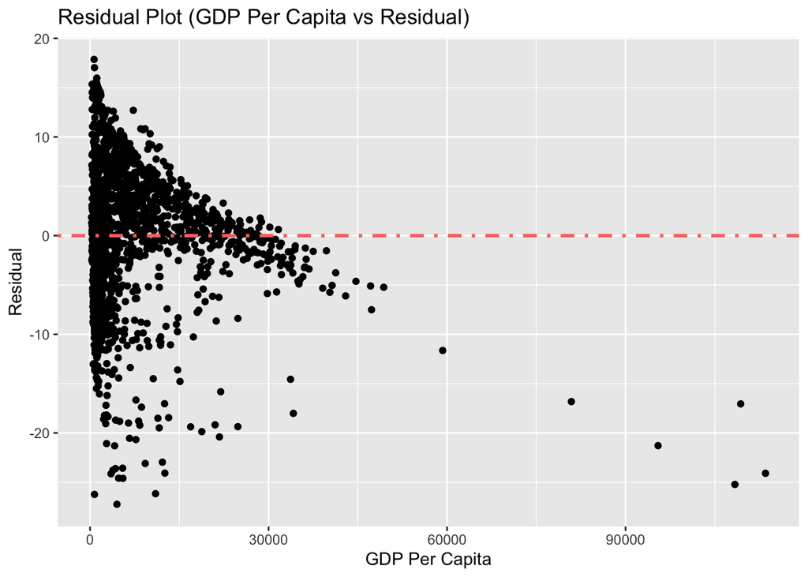

```r
predictions = predict.lm(object = modeladj, newdata = gapminder)

gapminder_predicted = gapminder %>%
  mutate(Fitted = predictions) %>%
  mutate(residual = lifeExp - predictions)

gapminder_predicted %>%
  ggplot(aes(x = gdpPercap, y = residual)) +
  geom_point() +
  geom_hline(aes(yintercept = 0, color = "red"),
             linetype = "dotdash",
             size = 1) +
  labs(x = "GDP Per Capita", y = "Residual", title = "Residual Plot (GDP Per Capita vs Residual)") +
  theme(legend.position = "none")
```

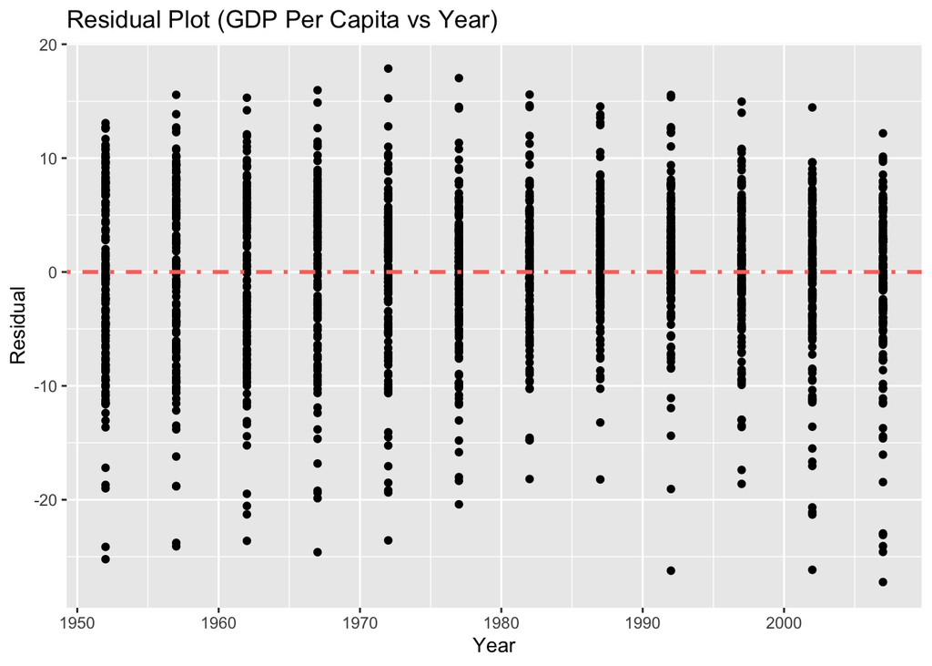

```r
gapminder_predicted %>%
  ggplot(aes(x = year, y = residual)) +
  geom_point() +
  geom_hline(aes(yintercept = 0, color = "red"),
             linetype = "dotdash",
             size = 1) +
  labs(x = "Year", y = "Residual", title = "Residual Plot (GDP Per Capita vs Year)") +
  theme(legend.position = "none")
```

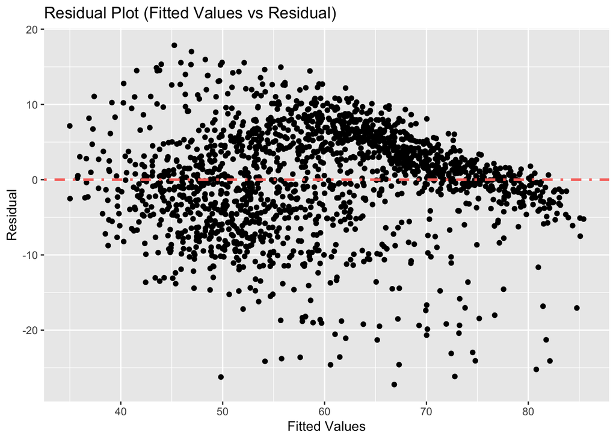

```r
gapminder_predicted %>%
  ggplot(aes(x = Fitted, y = residual)) +
  geom_point() +
  geom_hline(aes(yintercept = 0, color = "red"),
             linetype = "dotdash",
             size = 1) +
  labs(x = "Fitted Values", y = "Residual", title = "Residual Plot (Fitted Values vs Residual)") +
  theme(legend.position = "none")
```

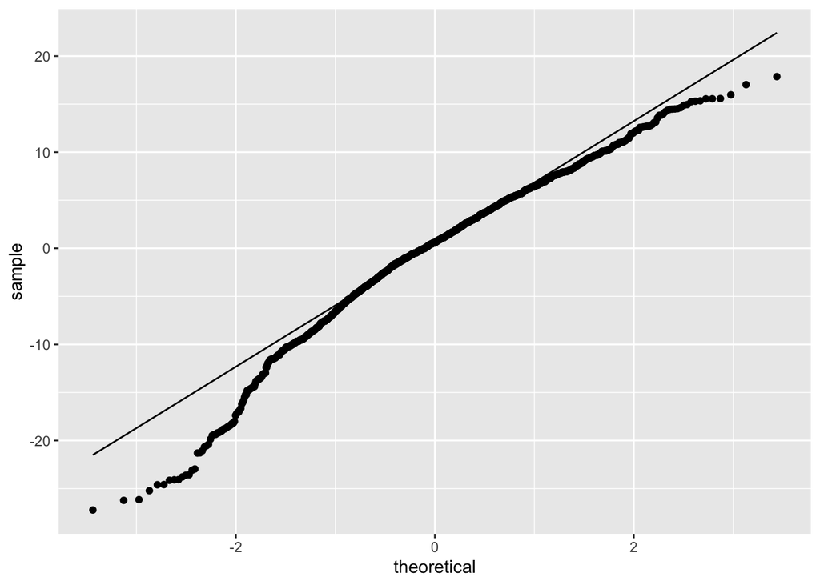

```r
gapminder_predicted %>%
  ggplot(aes(sample = residual)) +
  stat_qq() +
  stat_qq_line()
```

### Conclusion

R is awesome! You should teach with it for several reasons:

Free, easily accessable (unless you are on a government network), reproducable, relativly easy…

### Overarching questions:

1. Does the introduction do what we want it to do?
2. Does the tutorial piece speak correctly? Meaning, should it be more like, “we find students benefit from this:” vs what it is currently: “Here, let me teach you the following”
3. Should we mention how to actually execute a line of code or are we assuming that?

### text from prior draft left below for salvaging

## An example of how to cite in R

With more than 275 practical recipes, this expanded edition[^2] helps you perform data analysis with R quickly and efficiently. The R language[^3] provides everything you need to do statistical work, but its structure can be difficult to master. These task-oriented recipes make you productive with R immediately. Solutions range from basic tasks to input and output, general statistics, graphics, and linear regression.

Each recipe addresses a specific problem and includes a discussion that explains the solution and provides insight into how it works. If you’re a beginner, R Cookbook will help get you started. If you’re an intermediate user, this book will jog your memory and expand your horizons Grolemund and Wickham.[^4] You’ll get the job done faster and learn more about R in the process.

#### R Studio Layout

One of the most common mistakes I run into in class on day one is for beginners to try to run R directly from the console. They have R Studio downloaded, but do not understand the difference between R and R studio. R is the program that executes all commands you provide. It is the engine of the car, if you will. R Studio is the shell that keeps the user organized. R Studio is the shell around the car. To continue, it is the steering wheel, accelerator, brakes, and seatbelts.

To ensure you have opened R Studio, you screen should be broken into 3 to 4 panels.

Many new users also make the mistke of not realizing that they have not opened up a script. They begin executing in the console again and do not take advantage of the ease that scripts provide in writing reproducable code.

Possibly note on how to execute lines of code. Both code chuncks and specific lines of code.

### Tidyverse

## Installation

paraphrase what’s in R Cookbook?

### Installing R

### Installing R Studio

### Installing the Tidyverse

## Using R

### Loading Data

### Plotting

quick intro to ggplot

That graphical tool for ggplot?

### Plotting Multivariate Data

ggpairs?

# Bibliography

Allaire, JJ, Yihui Xie, Jonathan McPherson, Javier Luraschi, Kevin Ushey, Aron Atkins, Hadley Wickham, Joe Cheng, Winston Chang, and Richard Iannone. *Rmarkdown: Dynamic Documents for R*, 2019. https://CRAN.R-project.org/package=rmarkdown.

Grolemund, Garrett, and Hadley Wickham. “R for Data Science.” *R for Data Science*, n.d. https://r4ds.had.co.nz/.

Smith, Adam, and Alan B. Krueger. “The Wealth of Nations.” Bantam Classics, 2003.

Teetor, Paul, and JD Long. “R Cookbook, 2nd Edition,” n.d. http://www.cookbook-r.com/.

Xie, Yihui. *Knitr: A General-Purpose Package for Dynamic Report Generation in R*, 2019. https://CRAN.R-project.org/package=knitr.

[^1]: Smith and Krueger, “The Wealth of Nations.”
[^2]: Teetor and Long, “R Cookbook, 2nd Edition.”
[^3]: Allaire et al., *Rmarkdown*; Xie, *Knitr*.
[^4]: “R for Data Science.”